# Re-imagining a Data Visualization: Good Schools, Affordable Homes (New York Times)

Luke Smith

2017-05-12

A few weeks ago, a [Junk Charts post](http://junkcharts.typepad.com/junk_charts/2017/04/sorting-out-whats-meaningful-and-whats-not.html) critical of the New York Times article, [Good Schools, Affordable Homes: Finding Suburban Sweet Spots](https://www.nytimes.com/interactive/2017/03/30/upshot/good-schools-affordable-homes-suburban-sweet-spots.html), provided a few recommendations and criticisms for improving the data visuals within the article.

Here they are summarized:

1. Add a legend to explain the differences in the size of the dots (population?)
2. Explain the horizontal scale (x-axis = grad above or below national or state average?)
3. Aggregate the data (by metro area and commute time)

I decided to take the NYT data and plot it out in R while taking into account the considerations above, as best I can.

### Imitating the Original Work

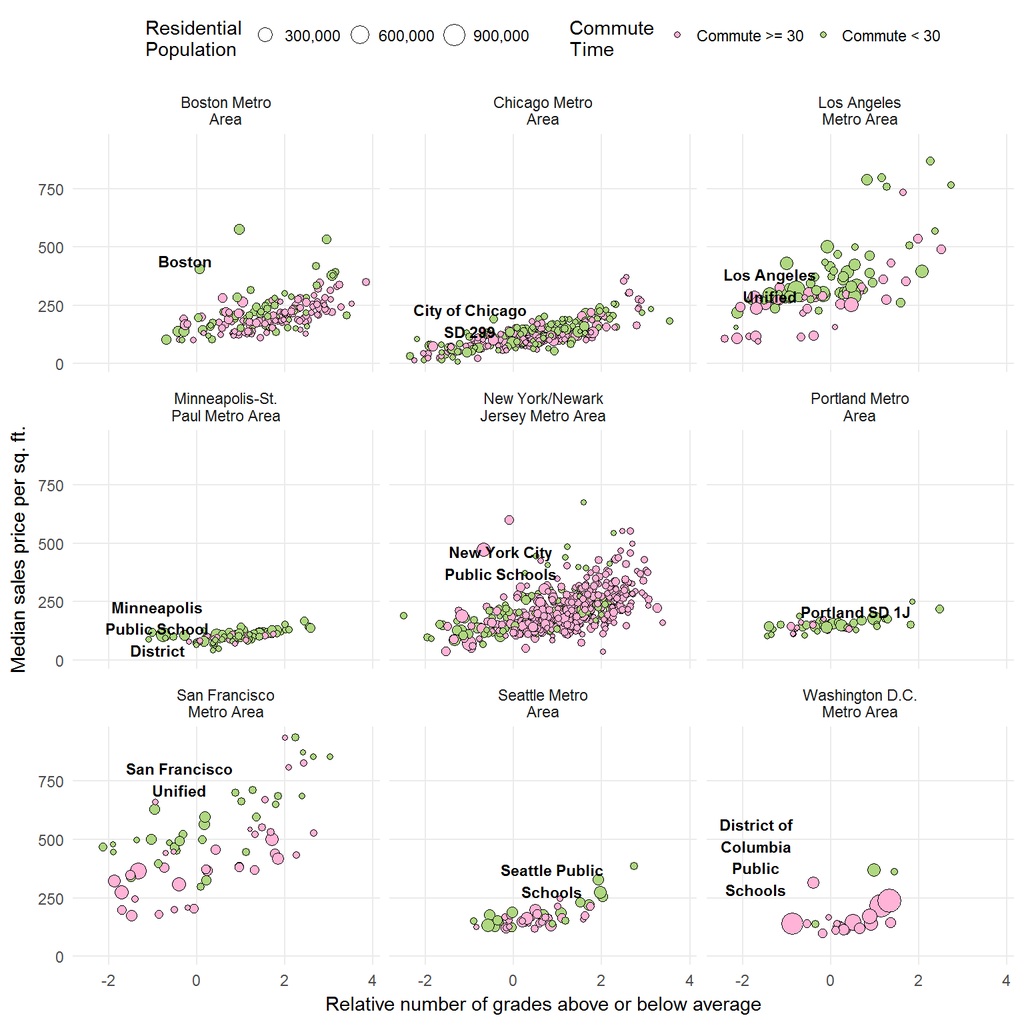

As you can see, the NYT dataset includes metro areas other than those mentioned in the article: Los Angeles, Seattle, Portland, and Washington D.C. I did my best to find a “central city” school district and plot that data as well.

### Re-imagined

I want to show you how the graph above would appear if it were faceted by whether the commute time were < 30 minutes or >= 30 minutes.

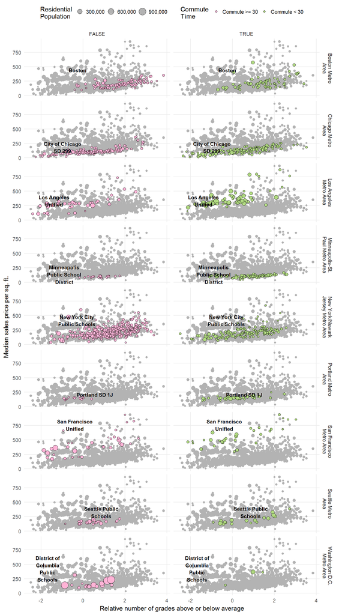

This does not reveal as much as I had anticipated.

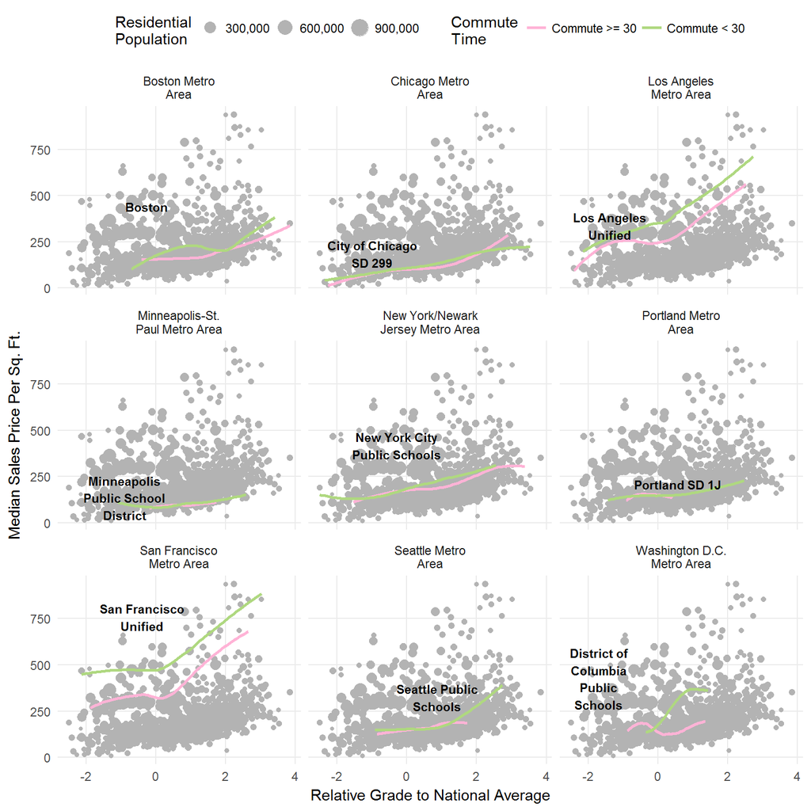

That still doesn’t quite show the relationship between commute time and relative grade. I went back to the point plot and added an extra facet: the commute time ranges.

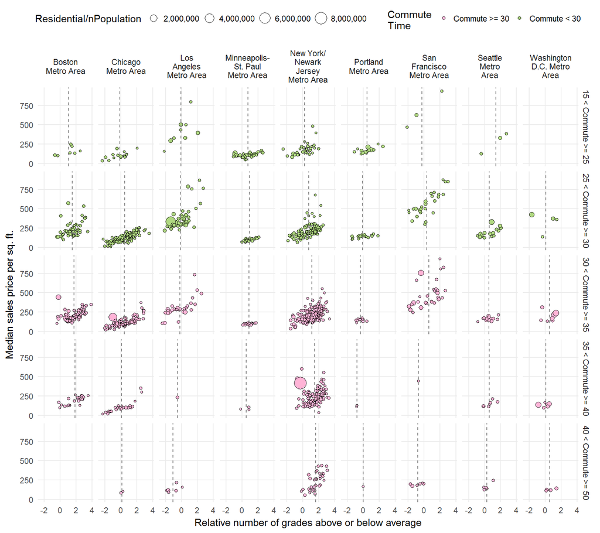

### Aggregated

To aggregate each district’s data:

- I grouped by region and whether the commute was less than 30 minutes or not
- Multiplied each district’s data by it’s residential population and then divide by the region’s total residential population
- Summed each grouping

It looked something like this:

```r
data %>%
  group_by(cbsa_title, `Commute Time`) %>%
  summarize(Population = sum(total_population),
            grade_mean = sum((gsmean_pool * total_population) / Population),
            sale_price_mean = sum((median_sale_price_per_sqft * total_population) / Population))
```

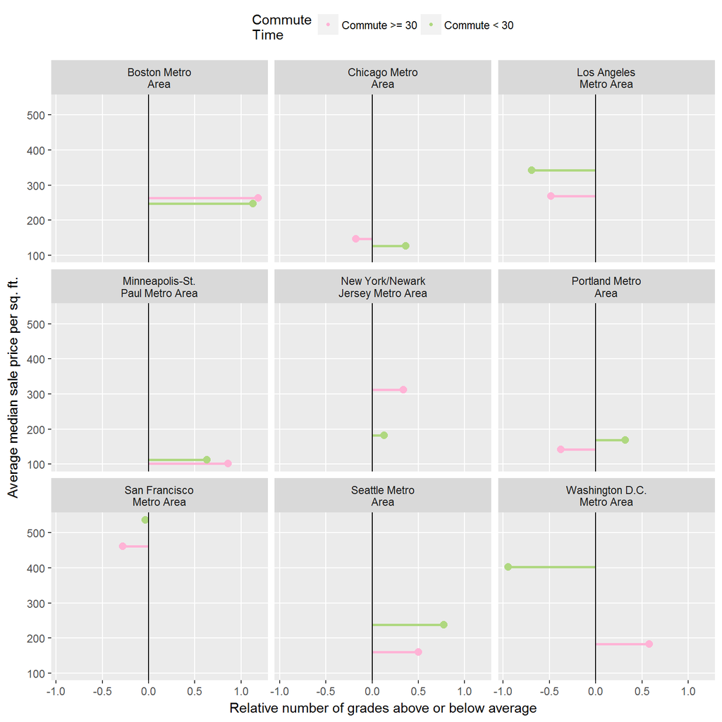

### Conclusion

I had to make a number of assumptions (or ignore certain things) to make the plots above.

1. The size of the dots appears proportional to the population variable in the data set, and so I mapped the `total_population` variable to the dot size.
2. The horizontal axis is some kind of relative grading scale. Sadly, the variable name did not help clarify much more.

Despite my limitations, the above graphs now show the scale for dot size, give more clarity to what are the x-axis values (though not definitively), and, as a bonus, show all the data points in the background (gray). This, I believe would be a great idea, if the grading scale were a national scale.